# CLASS STA101 - HW 1

Wangqian Miao

### Problem 1

**(a)**

Firstly, I should know the head of the data.

```
##     Location PovPct Brth15to17
## 1    Alabama   20.1       31.5
## 2     Alaska    7.1       18.9
## 3    Arizona   16.1       35.0
## 4   Arkansas   14.9       31.6
## 5 California   16.7       22.6
## 6   Colorado    8.8       26.2
```

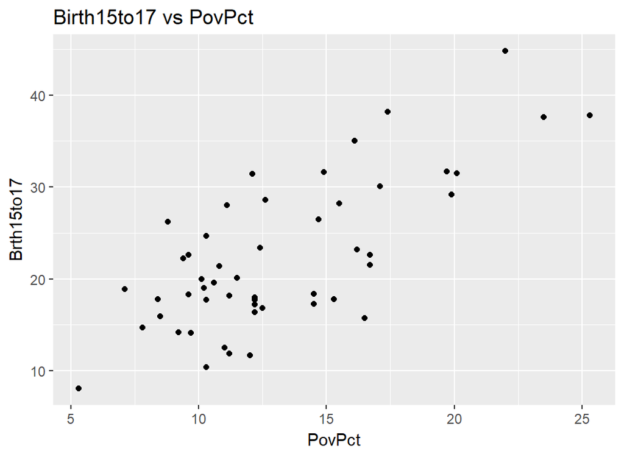

From the scatter plot, it shows that there may be a linear relationship between “Brth15to17” and “PovPct”.

**(b)**

```
## [1] 0.7302931
```

The estimated correlation is 0.7302931 which is near to 1. So, I think there is a strong linear relationship between “Brth15to17” and “PocPct”.

**(c)**

```
##    Min. 1st Qu.  Median    Mean 3rd Qu.    Max.
##    5.30   10.25   12.20   13.12   15.80   25.30
```

**(d)**

I can use boxplot to show whether there is any outliers in this data. So I know that there is an outlier in Brth15to17.

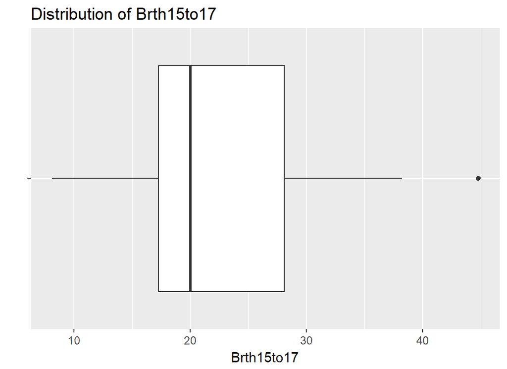

**(e)**

The appropriate range $mean\pm3\sigma$. It is from 0.285962 to 25.9493321.

### Problem 2

**(a)**

```
## (Intercept)      PovPct
##    4.267293    1.373345
```

The linear regression function is $\hat{y}=4.2673+1.3733X_1$

**(b)**

The slope $\beta_1$ is 1.3733. It means when “PocPct” adds one unit, the “Brth5to17” will add 1.3733 unit on average.

**(c)**

I think it is not appropricate. In my opinion if there are people, there will be people in poverty. So PovPct should not be 0.

**(d)**

The predict value of Brth15to17 for a state with poverty level 10% is 18.0003.

**(e)**

```
## Analysis of Variance Table
##
## Response: Brth15to17
##           Df Sum Sq Mean Sq F value    Pr(>F)
## PovPct     1 1725.3 1725.26  55.999 1.188e-09 ***
## Residuals 49 1509.6   30.81
## ---
## Signif. codes:  0 '***' 0.001 '**' 0.01 '*' 0.05 '.' 0.1 ' ' 1
```

The value of $R^{2}$ is 0.533328. It means when we use the model of linear regression, we can reduce the error by 53.33% approximately than we use the average number to predict.

### Problem 3

**(a)**

```
##   days  fitness
## 1   23 BelowAve
## 2   25 BelowAve
## 3   21 BelowAve
## 4   22 BelowAve
## 5   21 BelowAve
## 6   22 BelowAve
```

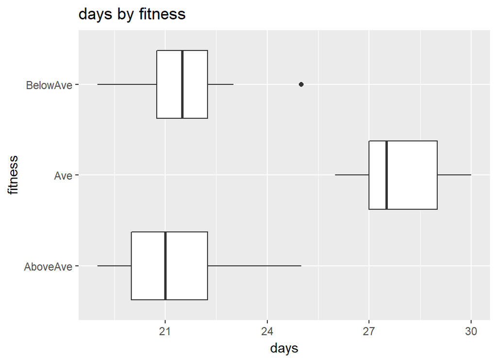

**(b)**

According to the boxplot, it shows that there is an outlier in the case of “BelowAve”.

**(c)**

**(d)**

The Five STA number is below.

```
##    Min. 1st Qu.  Median    Mean 3rd Qu.    Max.
##   19.00   21.00   22.50   23.56   27.00   30.00
```

**(e)**

I think outlier exists in the data when we use the boxplot by group. It is obvious when you refer to (a).

### Problem 4

**(a)**

```
##     (Intercept)      fitnessAve fitnessBelowAve
##         21.4167          6.3333          0.0833
```

```
## [1] BelowAve Ave      AboveAve
## Levels: AboveAve Ave BelowAve
```

The regression line is $\hat{y}=21.4167+6.3333X_1+0.0833X_2$.

**(b)**

The days needed for a successful completion therapy tends to increase by 6.3333 ($\beta_1$) days on average when the fitness level is Ave instead of AboveAve.

**(c)**

The days needed for a successful completion therapy tends to increase by 0.0833 ($\beta_2$) days on average when the fitness level is BelowAve instead of AboveAve.

**(d)**

When the fitness level is AboveAve, it needs 21.4167($\beta_0$) days for a successful completion of therapy on average.

**(e)**

AboveAve: $\hat{y}=21.4167$  
Ave: $\hat{y}=27.75$  
BelowAve: $\hat{y}=21.5$

### Problem 5

**(a)**

```
##   InfctRsk MedSchool  Stay
## 1      4.1        No  7.13
## 2      1.6        No  8.82
## 3      2.7        No  8.34
## 4      5.6        No  8.95
## 5      5.7        No 11.20
## 6      5.1        No  9.76
```

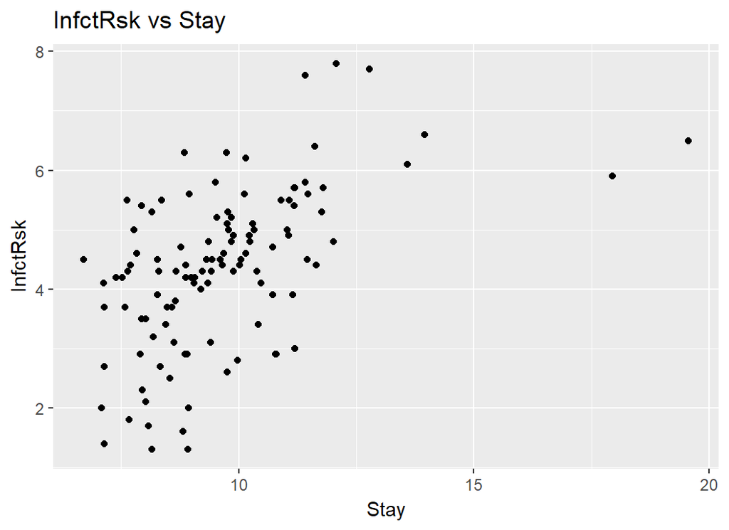

**(b)**

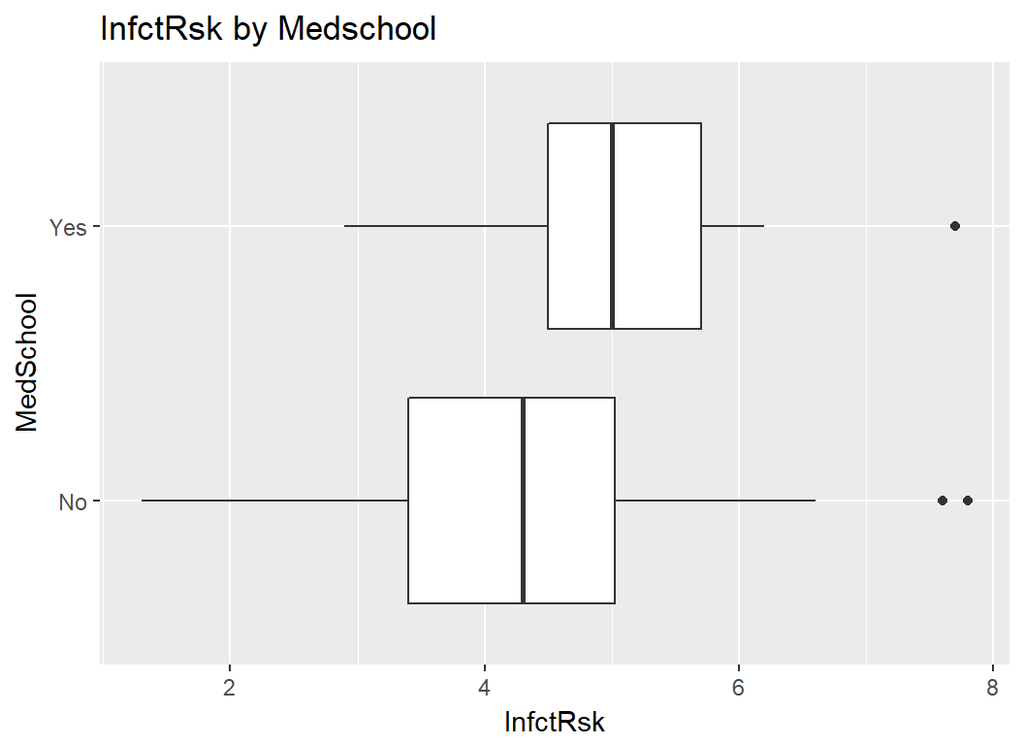

From the boxplot, it shows that there is a difference whether the hospital was associated with a Medschool.

**(c)**

The corelation is 0.5334438.

**(d)**

There are some outliers. As shown in the boxplot, there are some outliers aroud the line when “InfctRsk is 8”.

**(e)**

From the minimum of 3.9139505 to maximum 15.3826866.

### Problem 6

**(a)**

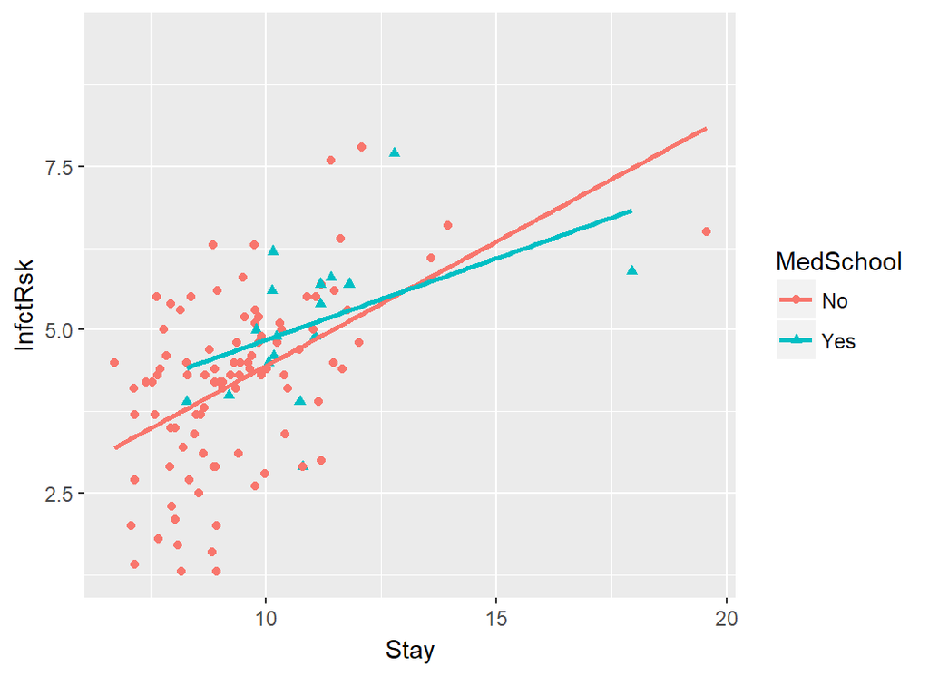

$\hat{y}=0.8628+0.3056X_1+0.3572X_2$. ($X_2$: Stay days, $X_1=0\rightarrow$ without a MedSchool, $X_1=1\rightarrow$ with a MedSchool.)

**(b)**

```
##  (Intercept) MedSchoolYes         Stay
##       0.8628       0.3056       0.3572
```

```
## [1] No  Yes
## Levels: No Yes
```

```
##
## Call:
## lm(formula = InfctRsk ~ ., data = hos)
##
## Coefficients:
##  (Intercept)  MedSchoolYes          Stay
##       0.8628        0.3056        0.3572
```

Without a Medschool: $\hat{y}=0.8628+0.3572X_2$  
With a Medschool: $\hat{y}=1.1684+0.3572X_2$

**(c)**

When the hospital was associated with a Medschool, the InfctRsk tends to increase by 0.3056($\beta_1$) percent on average compared to the hospital without a Medschool.

**(d)**

When the length of days patients stay in the hospital adds one day, the InfctRSk increases 0.3572($\beta_2$) percent on average.

**(e)**

The estimated value is 3.3629964.

### Problem 7

**(a)**

```
##
## Call:
## lm(formula = InfctRsk ~ MedSchool + Stay + MedSchool * Stay,
##     data = hos)
##
## Coefficients:
##       (Intercept)       MedSchoolYes               Stay
##            0.6368             1.7132             0.3812
## MedSchoolYes:Stay
##           -0.1315
```

The regression function is $\hat{y}=0.6368+1.7132X_{1}+0.3812X_{2} -0.1315X_{1}X_{2}$.

**(b)**

**(c)**

**(d)**

**(e)**

The estimated value is 3.3051 in the case of “MedSchool=No, Stay=7”.

### Problem 8

**(a)**

FALSE, correlation just measures the linear relationship.

**(b)**

FALSE, it will change the estimated value, because it is another model.

**(c)**

TRUE. When $0<r\leq1$, it means when $X$ increases, $Y$ increases. When $-1\leq r<0$, it means when $X$ increases, $Y$ decreases.

**(d)**

TRUE. It means that $\hat{y_i}<y_i$ and that suggests we underestimated $y_i$.

### R Appendix

```r
mydata=read.csv("poverty.csv",sep = ',',header = TRUE)
head(mydata)
library(ggplot2)
qplot(PovPct,Brth15to17,data=mydata)+ggtitle("Birth15to17 vs PovPct")
cor(mydata$PovPct,mydata$Brth15to17)
summary(mydata$PovPct)
ggplot(mydata,aes(y=Brth15to17,x = factor("")))+geom_boxplot()+ylab("Brth15to17") + xlab(" ")+ coord_flip() + ggtitle("Distribution of Brth15to17")
the.model=lm(Brth15to17~PovPct,data=mydata)
the.betas = round(the.model$coefficients,4)
the.model$coefficients


xs=10
ys=the.betas[1]+the.betas[2]*xs

anova.table= anova(the.model)
anova.table
the.things = summary(the.model)
R2 = the.things$r.squared
rehab=read.csv("rehab.csv",sep = ',',header = TRUE)
head(rehab)
ggplot(rehab,aes(y = days,x =fitness)) + geom_boxplot() + ylab("days") + xlab("fitness") + ggtitle("days by fitness") + coord_flip()


summary(rehab$days)
the.model=lm(days~fitness,data=rehab)
the.betas=round(the.model$coefficients,4)
the.betas
unique(rehab$fitness)



library(ggplot2)
hos=read.csv("hospital.csv",sep =',',header = TRUE)
head(hos)
qplot(Stay,InfctRsk,data=hos)+ggtitle("InfctRsk vs Stay")
ggplot(hos,aes(y =InfctRsk ,x =MedSchool)) + geom_boxplot() + ylab("InfctRsk") + xlab("MedSchool") + ggtitle("InfctRsk by Medschool") + coord_flip()


the.sd = sd(hos$Stay)
the.mean=mean(hos$Stay)
the.model = lm(InfctRsk ~ .,data= hos)
the.betas = round(the.model$coefficients,4)
ggplot(hos,aes(y = InfctRsk, x =Stay,colour=MedSchool,shape=MedSchool)) + geom_point() + geom_smooth(method="lm",fill = NA)
the.betas
unique(hos$MedSchool)
the.model


x.star=data.frame(Stay=7,MedSchool="No")
y.star=predict(the.model,x.star)
the.line=lm(InfctRsk~MedSchool+Stay+MedSchool*Stay, data=hos)
the.coef=round(the.line$coefficients, 4)
the.line



x.star=data.frame(MedSchool="No",Stay=7)
y.star=round(predict(the.line, x.star),4)
```